# Pattern Recognition

```python
from ipypublish import nb_setup
```

Pattern Recognition is the task of classifying an image into one of several different categories. Since their inception, Pattern Recognition is the most common problem that NNs have been used for, and over the years the increase in classification accuracy has served as an indicator of the state of the art in NN design. The MNIST pattern recognition problem served as a benchmark for DLN systems until recently, and in this section we introduce DLNs by describing the problem and the way in which they are used to solve it.

## MNIST

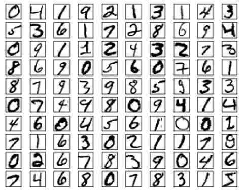

```python
#Mnist
nb_setup.images_hconcat(["DL_images/mnist.png"], width=600)
```

The MNIST database consists of 70,000 scanned images of handwritten digits from 0 to 9, a few of which are shown in Figure **Mnist**. Each image has been digitized into a $28 \times 28$ grid, with each of the 784 pixels in the grid assigned a quantized grayscale value between 0 and 1, with 0 representing white and 1 representing black. These numbers are then fed into a DLN as shown in Figure **mnistNN**. We will go into the details of the DLN architecture in Chapter **NNDeepLearning**, but at a high level the reader can observe that the DLN shown in Figure **mnistNN** has three layers of nodes (or neurons). The layer on the left is the Input Layer and consists of 784 neurons, with each neuron assigned a number with the grayscale value of the corresponding pixel from the input image. Note that the 2-dimensional image has been stretched out into a 1-demensional vector before being fed into the DLN. The middle layer is called the Hidden Layer and consists of 15 neurons, while the third layer is called the Output Layer and consists of 10 neurons. As the name implies, the Output Layer indicates the output of the DLN computation, so that ideally if the input corresponds to the digit $k$, $0 \leq k \leq 9$ , then the $k^{th}$ output neuron should be 1, and the other 9 should be zero.

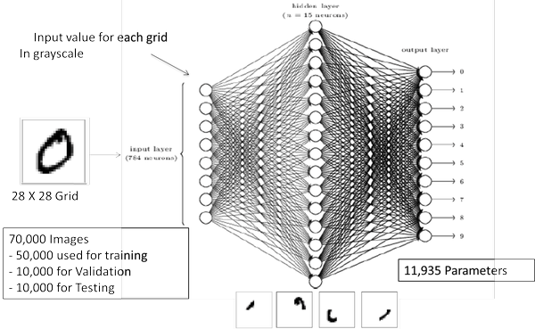

```python
#mnistNN
nb_setup.images_hconcat(["DL_images/mnistNN.png"], width=600)
```

The neurons in the Input and Hidden Layers are fully connected which implies that each neuron in the input layer is connected to every neuron in the Hidden Layer (and the same goes for the neurons between the Hidden and Output Layers). Note that these connections are uni-directional, i.e. exist in the forward direction only. Each of these connections is assigned a weight and each node in the Hidden and Output layers is assigned a bias, so that there are a total of $784 \times 15 + 15 \times 10 +15 +10 = 11,935$ weight + bias parameters needed to describe the network.

In an operational network, these 11,935 weight and bias parameters have to be set, so that the DLN is able to do its job. The process of choosing these parameters is known as "training the network" and uses a learning algorithm that proceeds by iteration. After the training is complete, the DLN should be able to classify images of digits that were not part of the training dataset, which is known as the networks "Generalization Ability".

## Epoch Accuracy

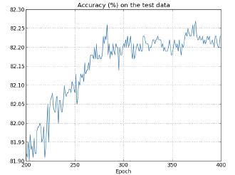

```python
#epochAccuracy
nb_setup.images_hconcat(["DL_images/epochAccuracy.png"], width=1000)
```

Figure **epochAccuracy** plots the accuracy of the classification process as a function of the number of Epochs using the test data set. As can be seen, the classification accuracy increases almost linearly initially, but after about 260 Epochs, the classification accuracy does not increase beyond 82.25% or so (in other words the NN classifies about 8225 images correctly out of a total of 10,000 Test Images). The reasons why the testing accuracy plateaus out and what can be done to increase it further forms the subject of Section **ImprovingModelGeneralization**. In practice, the best accuracy that has been achieved by a state of the art NN on the MNIST classification problem is about 99.67%, i.e., only 33 mis-classifications out of 10,000!

Figure **mnistNN** also provides some insight into how the DLN is able to carry out the classification task, for the example in which the input is a handwritten zero. In a trained NN, four of the nodes in the Hidden layer are tuned to recognize the presence of dark pixels in certain parts of the image, as shown in the bottom of the figure. This is done by appropriately choosing the weights on the links between the Input and Hidden layers, which is also called filtering. As shown in the figure, the output node that corresponds to the digit 0, filters these 4 Hidden layer nodes (by setting the weights on the links between the Hidden and Output layers), such that its own output tends towards 1, while the outputs of the other nodes in the Output layer tend towards 0.

## ImageNet Large-Scale Visual Recognition Challenge (ILSVRC)

# ILSVRC

## Keras Implementation of the MNIST Classifier

There are several frameworks that have emerged in the last few years for implementing DLN models. One of the most popular is Keras, which is built on top of an earlier framework called TensorFlow (both are from Google). We show an implementation of the MNIST classifier using Keras.

```python
import keras
keras.__version__
from keras import models
from keras import layers
```

The MNIST dataset comes pre-loaded in Keras, and the next command imports it into the model. The raw MNIST images are in a format such as .png or .jpg, however these have been pre-processed by Keras into the Grayscale format, so that each pixel is an integer between 0 and 255. Furthermore all the images have been converted into a tensor format that can be processed using Keras. Also note that the images have been already split into training and test datasets.

```python
from keras.datasets import mnist

(train_images, train_labels), (test_images, test_labels) = mnist.load_data()
```

Using the shape command, we obtain the dimensions of the tensor containing the training data. As shown below, the training dataset is a 3 dimensional tensor, with the first dimension representing the number of training images, and the next two dimensions representing the size of each image. Each image is a two dimensional tensor of size 28 x 28.

```python
train_images.shape
```

```
(60000, 28, 28)
```

The labels for the training data form an array of size 60,000. An element of this array is an integer label for the corresponding image.

```python
len(train_labels)
```

```
60000
```

```python
train_labels
```

```
array([5, 0, 4, ..., 5, 6, 8], dtype=uint8)
```

Similarly for test images:

```python
test_images.shape
```

```
(10000, 28, 28)
```

```python
len(test_labels)
```

```
10000
```

```python
test_labels
```

```
array([7, 2, 1, ..., 4, 5, 6], dtype=uint8)
```

We can also plot one of the training images by using the matplotlib commnd:

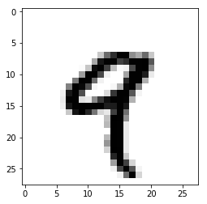

```python
digit = train_images[4]

import matplotlib.pyplot as plt
import numpy as np
plt.imshow(digit, cmap = plt.cm.binary)
plt.show()
```

The contents of this image cal also be displayed in matrix form. Note that each pixel is represented in the Grayscale format by an integer in the range 0 and 255.

```python
digit
```

```
array([[  0,   0,   0,   0,   0,   0,   0,   0,   0,   0,   0,   0,   0,
          0,   0,   0,   0,   0,   0,   0,   0,   0,   0,   0,   0,   0,
          0,   0],
       [  0,   0,   0,   0,   0,   0,   0,   0,   0,   0,   0,   0,   0,
          0,   0,   0,   0,   0,   0,   0,   0,   0,   0,   0,   0,   0,
          0,   0],
       [  0,   0,   0,   0,   0,   0,   0,   0,   0,   0,   0,   0,   0,
          0,   0,   0,   0,   0,   0,   0,   0,   0,   0,   0,   0,   0,
          0,   0],
       [  0,   0,   0,   0,   0,   0,   0,   0,   0,   0,   0,   0,   0,
          0,   0,   0,   0,   0,   0,   0,   0,   0,   0,   0,   0,   0,
          0,   0],
       [  0,   0,   0,   0,   0,   0,   0,   0,   0,   0,   0,   0,   0,
          0,   0,   0,   0,   0,   0,   0,   0,   0,   0,   0,   0,   0,
          0,   0],
       [  0,   0,   0,   0,   0,   0,   0,   0,   0,   0,   0,   0,   0,
          0,   0,   0,   0,   0,   0,   0,   0,   0,   0,   0,   0,   0,
          0,   0],
       [  0,   0,   0,   0,   0,   0,   0,   0,   0,   0,   0,   0,   0,
          0,   0,   0,   0,   0,   0,   0,   0,   0,   0,   0,   0,   0,
          0,   0],
       [  0,   0,   0,   0,   0,   0,   0,   0,   0,   0,   0,   0,  55,
        148, 210, 253, 253, 113,  87, 148,  55,   0,   0,   0,   0,   0,
          0,   0],
       [  0,   0,   0,   0,   0,   0,   0,   0,   0,   0,   0,  87, 232,
        252, 253, 189, 210, 252, 252, 253, 168,   0,   0,   0,   0,   0,
          0,   0],
       [  0,   0,   0,   0,   0,   0,   0,   0,   0,   4,  57, 242, 252,
        190,  65,   5,  12, 182, 252, 253, 116,   0,   0,   0,   0,   0,
          0,   0],
       [  0,   0,   0,   0,   0,   0,   0,   0,   0,  96, 252, 252, 183,
         14,   0,   0,  92, 252, 252, 225,  21,   0,   0,   0,   0,   0,
          0,   0],
       [  0,   0,   0,   0,   0,   0,   0,   0, 132, 253, 252, 146,  14,
          0,   0,   0, 215, 252, 252,  79,   0,   0,   0,   0,   0,   0,
          0,   0],
       [  0,   0,   0,   0,   0,   0,   0, 126, 253, 247, 176,   9,   0,
          0,   8,  78, 245, 253, 129,   0,   0,   0,   0,   0,   0,   0,
          0,   0],
       [  0,   0,   0,   0,   0,   0,  16, 232, 252, 176,   0,   0,   0,
```

[output cut: 29 more lines]

```
       [  0,   0,   0,   0,   0,   0,   0,   0,   0,   0,   0,   0,   0,
          0, 218, 252,  56,   0,   0,   0,   0,   0,   0,   0,   0,   0,
          0,   0],
       [  0,   0,   0,   0,   0,   0,   0,   0,   0,   0,   0,   0,   0,
          0,  96, 252, 189,  42,   0,   0,   0,   0,   0,   0,   0,   0,
          0,   0],
       [  0,   0,   0,   0,   0,   0,   0,   0,   0,   0,   0,   0,   0,
          0,  14, 184, 252, 170,  11,   0,   0,   0,   0,   0,   0,   0,
          0,   0],
       [  0,   0,   0,   0,   0,   0,   0,   0,   0,   0,   0,   0,   0,
          0,   0,  14, 147, 252,  42,   0,   0,   0,   0,   0,   0,   0,
          0,   0],
       [  0,   0,   0,   0,   0,   0,   0,   0,   0,   0,   0,   0,   0,
          0,   0,   0,   0,   0,   0,   0,   0,   0,   0,   0,   0,   0,
          0,   0]], dtype=uint8)
```

The Grayscale formatted image tensors cannot be fed directly into the model, but need to be pre-processed, as follows:

1. The DLN model in Figure **mnistNN** can only accept input that is in the form of an 1-D array, or a vector. So we need to convery the 2-D tensors into a vector, which is done using the numpy reshape command.
2. The data being fed into the NN has to be normalized so that all numbers are around zero in magnitude, otherwise the training does not work very well. This is done by dividing each of the Grayscale formatted pixel values by 255, so that they lie in the range [0,1] after normalization.

```python
train_images = train_images.reshape((60000, 28 * 28))
train_images = train_images.astype('float32') / 255

test_images = test_images.reshape((10000, 28 * 28))
test_images = test_images.astype('float32') / 255
```

After re-shaping, the training dataset now consists of 60,000 images, each of which is a normalized vector of size 784.

```python
train_images.shape
```

```
(60000, 784)
```

There are two ways in which the output label can be specified in Keras:

1. Sparse Categorical: The label can be specified as an integer, as is the case for the MNIST data stored in Keras.
2. Categorical: In this case labels are specified in the 1-Hot Encoding format. For example if the label is the integer 'k' in the sparse categorical format, then it becomes an array in the categorical format, such that the $k^{th}$ entry in the array is 1, and all the other entries are 0.

The following commands convert all the labels in the training and test datasets to the categorical format.

```python
from tensorflow.keras.utils import to_categorical

train_labels = to_categorical(train_labels)
test_labels = to_categorical(test_labels)

train_labels
```

```
array([[0., 0., 0., ..., 0., 0., 0.],
       [1., 0., 0., ..., 0., 0., 0.],
       [0., 0., 0., ..., 0., 0., 0.],
       ...,
       [0., 0., 0., ..., 0., 0., 0.],
       [0., 0., 0., ..., 0., 0., 0.],
       [0., 0., 0., ..., 0., 1., 0.]], dtype=float32)
```

The NN model itself is specified using only 3 lines of Keras code.

Note that more layers can be added very simply to this model by repeating the command in Line 2.

```python
network = models.Sequential()
network.add(layers.Dense(15, activation='relu', input_shape=(28 * 28,)))
network.add(layers.Dense(10, activation='softmax'))
```

The compile command uses the following arguments:

- Specifying the Loss Function: The Loss Function is a measure of the difference between the output of the model vs the contents of the corresponding Label. The "Categorical Cross Entopy" Loss Function will be used. Note that if we had left the labels in the Sparse Categorical format, then the Loss Function "Sparse Categorical Cross Entropy" would be needed.
- Specifying the Optimization Algorithm: In this case we will use 'sgd' which stands for Stochastic Gradient Descent. These algorithms are all based on Backprop, which is an efficient way of computing gradients.
- Specifying the output metrics: This gives Keras the list of output metrics to collect. In this case we collect the "accuracy" metric, which is one of the Keras specified metrics. User defined metrics can also be specified here.

```python
network.compile(optimizer='sgd',
                loss='categorical_crossentropy',
                metrics=['accuracy'])
```

We are finally ready to train the model, which is done using the fit command. The fit command is invoked using the following arguments:

- The list of Training Images and Training Labels
- The number of epochs the training should be done for. Recall that each epoch corresponds to passing the entire training dataset through the model
- Typically data is not fed into the model one at a time, but in batches of size batch_size. This is done in order to improve the convergence properties of the algorithm
- The validation_split value allows the system to set aside the specified fraction of training data for validation purposes

Once the training starts, Keras provides a periodic update at the end of each epoch. This update contains the time it took to finish the epoch as well as the trailing and validation loss and accuracy values.

```python
history = network.fit(train_images, train_labels, epochs=500, batch_size=128, validation_split=0.2)
```

The following command provides a list of performance data that Keras collected during the training. In this case we the training and validation loss and accuracy values, collected at the end of each training epoch.

```python
history_dict = history.history
history_dict.keys()
```

```
dict_keys(['loss', 'accuracy', 'val_loss', 'val_accuracy'])
```

We can plot the performance data collected during the training process using matplotlib. The plots shown below are typical for the loss and accuracy values as a function of the number of epochs. These plots are extremely important in interpreting and/or debugging the model, and in later chapters we will explain how this is done. By comparing the training and validation curves, we can figure how well the model is generalizing beyond the training dataset.

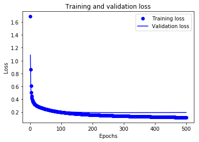

```python
import matplotlib.pyplot as plt

acc = history.history['accuracy']
val_acc = history.history['val_accuracy']
loss = history.history['loss']
val_loss = history.history['val_loss']

epochs = range(1, len(acc) + 1)
#epochs = range(1, len(loss) + 1)

# "bo" is for "blue dot"
plt.plot(epochs, loss, 'bo', label='Training loss')
# b is for "solid blue line"
plt.plot(epochs, val_loss, 'b', label='Validation loss')
plt.title('Training and validation loss')
plt.xlabel('Epochs')
plt.ylabel('Loss')
plt.legend()

plt.show()
```

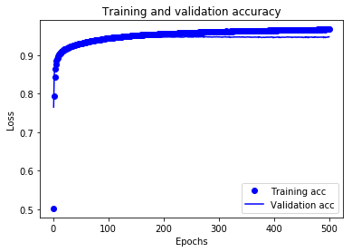

```python
plt.clf()   # clear figure
acc_values = history_dict['accuracy']
val_acc_values = history_dict['val_accuracy']

plt.plot(epochs, acc, 'bo', label='Training acc')
plt.plot(epochs, val_acc, 'b', label='Validation acc')
plt.title('Training and validation accuracy')
plt.xlabel('Epochs')
plt.ylabel('Loss')
plt.legend()

plt.show()
```

Once we are satisfied with the training results, we can run the test data through the model using the evaluate command.

```python
test_loss, test_acc = network.evaluate(test_images, test_labels)
```

```python
print('test_acc:', test_acc)
```

```
test_acc: 0.9492999911308289
```

The summary command provides a useful overview of the model, it lists all the layers, the shape of the output tensor as well as the number of parameters per layer.

```python
network.summary()
```

```
Model: "sequential"
_________________________________________________________________
Layer (type)                 Output Shape              Param #
=================================================================
dense (Dense)                (None, 15)                11775
_________________________________________________________________
dense_1 (Dense)              (None, 10)                160
=================================================================
Total params: 11,935
Trainable params: 11,935
Non-trainable params: 0
_________________________________________________________________
```